*Department of Computer Science and IT* | *La Trobe University, Australia*

# [STAFF ONLY] Programming Assignment (CSE1PE/PES 2025, Semester 1)

```python
STUDENT_NAME = 'Your name here'
STUDENT_ID = 'Your ID here'

# Note that assessors will be running all cells, including this cell so please do a "run all" before submitting.
```

**A key purpose of this assessment task is to test your own ability to complete the assigned tasks. Therefore, the use of ChatGPT, AI tools or chatbots with similar functionality is prohibited for this assessment task. Students who are found to be in breach of this rule will be subject to normal academic misconduct measures. Additionally, students may be engaged to provide an oral validation of their understanding of their submitted work (e.g. coding).**

## Instructions

- Read each task thoroughly multiple times to ensure that you understand the requirements.
- Once you understand the task, write your solution in the associated code cell titled "Your Solution". Your solution must consist of valid Python code which runs in Google Colab.
- Test your solution multiple times, with different values---not just those found in the example runs.
- Unless explicitly asked in the task, you are *not* required to validate user input, i.e. you can assume that the user will enter a valid input value.
- Keep in mind that partial attempts at solutions will likely still be worth some marks, so be sure to have a go at writing code for every task.

When you have satisfactorily attempted all tasks, confirm that your solution works by resetting the notebook runtime and running your code again---instructions can be found at the bottom of this notebook.

The submission for this assignment is the `.ipynb` notebook file. You should export this file and upload it via the link in the LMS---instructions can be found on the assignment submission page. Do not submit your solutions in any other format as they will not be graded.

## Marking

There are a total of 100 marks available for this assignment.

- Marks for individual tasks will be awarded according to the totals and criteria listed within each task description. Ensure that you pay close attention to the "Criteria" sections as you read through the assignment.
- Additionally, up to 12 marks will be awarded based on the overall quality of the submitted code. We will be checking for:
  - adherence to instructions
  - deliberate and intentional programming which demonstrates command of the Python language
  - consistency of coding style across solutions
  - overall readability and clarity of the code
- Late submissions will be penalised according to [University policy](https://policies.latrobe.edu.au/document/view.php?id=380&version=6) (reduction of 5 marks per **calendar** day up to a maximum of 5 days, after which point the submission will not be accepted).

## Frequently Asked Questions

> Q: The "Your Solution" cell contains some code in it already. Can I change that code however I want?

A: No. There are comments which clearly indicate where you should be writing your solution.

> Q: Can I import another Python module not mentioned in the assigment to help me write my solution?

A: No, only import modules when instructed to.

> Q: I want to write the code in a text editor such as Visual Studio Code. Can I submit `.py` files instead of using this notebook?

A: No, only `.ipynb` files will be graded---not `.py`, `.txt`, `.pdf`, `.docx`, `.html`, etc. If you really want to write your code in a text editor, ensure that you copy your solutions into the appropriate notebook cells afterwards and run them to make sure that they work correctly. You can then follow the usual submission procedure.

> Q: I'm getting ready for submission, but I can't open the downloaded `.ipynb` file on my computer. Is that a problem?

A: That's not a problem, we know how to open it to mark your assignment. If you want to double-check the contents of the downloaded `.ipynb` file for your own peace of mind, you can upload it to [Google Colab](https://colab.research.google.com/) and open it there.

> Q: There is a mismatch between the precision of values shown in the example runs and my solution's output (e.g. my code prints "$5588.2219172490795" but the example run shows "$5588.22"). Is it still possible to achieve full marks with this kind of discrepancy?

A: No, you would not receive full marks. Presenting program output in an intentional way is an important programming skill, and demonstrates command of the language. If you are having trouble with formatting output, refer back to Week 6 and "f-strings" in particular.

## Non-Programming Tasks

### Task 1: Academic Integrity reflection (5 marks)

In order to access this assignment, you were asked to read about an Academic Integrity issue and answer related multiple-choice questions. Before continuing on to the main programming tasks, take a moment to reflect on this issue by answering the questions below. If you have forgotten the details of the scenario, refer back to the LMS quiz as you answer this task.

**Questions:** Have any of Ioni, Rohan or Sami engaged in academic misconduct? Explain. Have their choices led to them learning the subject material better? What could be the possible outcomes for Ioni, Rohan and Sami now? What could they have done differently?

*Provide your answers by double-clicking on the text cell below and typing your complete response to the questions in no more than 150 words. You will not be marked based on the 'correctness' of your answer. Instead, you will gain marks for showing you have made a genuine attempt to think through these tricky issues, and for expressing your thoughts and reflections clearly.*

## Programming Tasks

The theme of this assignment is programming a text-based chatbot, similar to what you might be familiar with in software such as Discord, Telegram, or Slack. Note that we will be working with a "fake" chat environment only. That is, we won't actually be integrating with any real service (or connecting the chatbot to the Internet at all), so don't worry about trying things and making mistakes as you work towards your solutions.

Take your time to read and re-read the instructions before attempting to write your solution to a task---you can save a lot of trouble by simply having a clear understanding of the problem before touching any code.

### Task 2: Chatbot !whisper command (8 marks)

You will be creating a chatbot which responds to user chat messages that begin with an exclamation mark, such as `!hello`. For now we won't worry about actually detecting commands in user input and will instead focus on implementing the behaviour of the chatbot.

To begin with, run the code cell below. This code defines two functions, `chat_input()` and `bot_say()`, which you will use throughout the assignment. Understanding the details of the code in this particular cell is not important---suffice to say that these two functions will be used instead of `input()` and `print()` to make a colourful, chat-like display.

```python
# Run this cell, but do not edit it.
!pip install -q --progress-bar off rich==13.9.4

import rich.console
import rich.text
import time

console = rich.console.Console()

def chat_input():
    """Reads a line of chat input from the user. Use this instead of input().
    """
    time.sleep(0.2)
    return console.input(rich.text.Text('You:', style='blue bold'))

def bot_say(message):
    """Outputs a message from the chatbot. Use this instead of print().
    """
    text = rich.text.Text()
    text.append(f'Chatbot:\n', style='red bold')
    text.append(str(message))
    console.print(text)

print('Functions chat_input() and bot_say() have been defined successfully.')
```

We will implement each chatbot command as a separate function. For example, here is a function defining the behaviour of very simple `!hello` command which displays "Hello world!". Run it to see what it does.

```python
def bot_hello(payload):
    bot_say('Hello world!')

bot_hello([])
```

You may have noticed that the function above has a single parameter, `payload`. All of our chatbot command functions will have this parameter, regardless of whether the code in the function body uses it or not. This parameter allows the user to specify additional information to the bot in the form of a list of words (each word is a string). The chatbot can either ignore any additional information (as is the case in `bot_hello()`), or use it.

In summary, to implement the behaviour for a command `!something`, you need to define a function called `bot_something()` which has a `payload` parameter. The `payload` parameter represents the list of words typed after the command.

Let's now consider a `!whisper` command which uses this additional information. If the user types `!whisper I LOVE PYTHON`, then the function `bot_whisper()` will be called with the payload argument `['I', 'LOVE', 'PYTHON']`.

This enables more interesting bot behaviour based on extra information provided by the user. For example:

**You:**  
!whisper I LOVE PYTHON  
**Chatbot:**  
i love python

Your task is to implement the bot behaviour for `!whisper` by writing a function called `bot_whisper()`. The function should join the words in `payload` to form a single string, convert that string to lowercase letters, and then display it using `bot_say()`.

**Note:** After running the code cell containing your implementation of `bot_whisper()`, you can call the `bot_whisper()` function from any cell in this notebook.

To join all the separate words in a list together, use the `join()` string method. This method inserts the string that `join()` is called on between all of the words in the list, and returns the result as a single long string. Here's an example of its usage in an interactive Python interpreter session:

```
>>> ' '.join(['good', 'day'])
'good day'
```

There are two lines of code at the bottom of the following cell that test the `bot_whisper()` function by calling it. It is usually a good idea to test code with multiple different values so that you have more confidence that it is working correctly. Add a second test case below the existing one, but make up a different argument to test with.

#### Examples for testing

Use the examples below, as well as your own examples, to test your code. The output from your chatbot should exactly match what is shown here.

```
bot_whisper(['I', 'LOVE', 'PYTHON'])
```

**Chatbot:**  
i love python

```
bot_whisper(['ThERe', 'are', '8', 'HARRY', 'PottER', 'BoOks'])
```

**Chatbot:**  
there are 8 harry potter books

#### Criteria

- Joins list elements from `payload` to make a single string (2 marks).
- Converts the message to lowercase (2 marks).
- Correctly displays output by calling the `bot_say()` function (2 marks).
- Includes an additional test call to `bot_whisper()` with a different (but appropriately typed) argument (2 marks).

#### Your Solution

```python
def bot_whisper(payload):
    # Implement the body of the bot_whisper() function here.
    # Use bot_say() instead of print() to display output.
    pass


bot_whisper(['I', 'LOVE', 'PYTHON'])        #=> Chatbot: i love python
bot_whisper(['ThERe', 'are', '8', 'HARRY', 'PottER', 'BoOks'])  #=> Chatbot: there are 8 harry potter books

# Add another test call here
```

#### [STAFF ONLY] Sample Solution

```python
def bot_whisper(payload):
    message = ' '.join(payload)     # C1: 2 marks
    message = message.lower()       # C2: 2 marks
    bot_say(message)                # C3: 2 marks


bot_whisper(['I', 'LOVE', 'PYTHON'])
bot_whisper(['ThERe', 'are', '8', 'HARRY', 'PottER', 'BoOks'])

# Add another test call here
bot_whisper(['CSE1PE', 'is', 'my', 'favourite', 'subject'])   # C4: 2 marks
```

### Task 3: Chatbot !multiply command (10 marks)

You will now implement the behaviour for a `!multiply` chatbot command. For this command, you may assume that the user always provides two numbers, for example `!multiply 2.2 6`. Like the previous task, you only need to define the function and we will worry about accepting user input later.

*Hint: The `payload` argument for all of the chatbot commands will always be a list of strings. For the `bot_multiply()` function specifically, the first element of this list will be the first number (as a string) and the second element will be the second number (as a string). In order to perform multiplication, you will need to convert these elements to another type.*

When it comes to displaying the result, the chatbot must **show the full equation** with the answer inside it, not just the answer. The two numbers being multiplied must be displayed exactly as the user typed them (in the same order), and the answer must be displayed to 4 decimal places. So, if the user wants to multiply `2.50` by `2`, then the full chatbot output should be `2.50 * 2 = 5.0000`.

#### Examples for testing

Use the examples below, as well as your own examples, to test your code. The output from your chatbot should exactly match what is shown here.

```
bot_multiply(['2.2', '6'])
```

**Chatbot:**  
2.2 * 6 = 13.2000

```
bot_multiply(['2.50', '2'])
```

**Chatbot:**  
2.50 * 2 = 5.0000

```
bot_multiply(['0.225', '3.5'])
```

**Chatbot:**  
0.225 * 3.5 = 0.7875

#### Criteria

- Uses data from the payload to determine the numbers needed for multiplication. (3 marks)
- Performs multiplication using an appropriate expression. (1 mark)
- Converts elements in the payload to an appropriate type. (2 marks)
- Displays the result as an equation using the `bot_say()` function. (2 marks)
- Displays both numbers in the output exactly as the user typed them (in the same order), but the answer to 4 decimal places (see examples). (2 marks)

#### Your Solution

```python
def bot_multiply(payload):
    # Implement the body of the bot_multiply() function here.
    pass


bot_multiply(['2.2', '6'])      #=> Chatbot: 2.2 * 6 = 13.2000
bot_multiply(['2.50', '2'])     #=> Chatbot: 2.50 * 2 = 5.0000
bot_multiply(['0.225', '3.5'])  #=> Chatbot: 0.225 * 3.5 = 0.7875
```

#### [STAFF ONLY] Sample Solution

```python
def bot_multiply(payload):
    # C1: 1.5 marks per-variable unpacked
    first_num = payload[0]
    second_num = payload[1]
    # C2: Multiplication = 1 mark.
    # C3: Typecasting = 1 mark per-variable
    result = float(first_num) * float(second_num)
    # C4: 1 mark calling bot_say.
    # C4: 1 mark formatted as a * b = c
    # C5: 1 mark payload variables displayed as given
    # C5: 1 mark output shown to 4dp
    bot_say(f'{first_num} * {second_num} = {result:.4f}')


bot_multiply(['2.2', '6'])      #=> Chatbot: 2.2 * 6 = 13.2000
bot_multiply(['2.50', '2'])     #=> Chatbot: 2.50 * 2 = 5.0000
bot_multiply(['0.225', '3.5'])  #=> Chatbot: 0.225 * 3.5 = 0.7875
```

### Task 4: Chatbot !count command (15 marks)

Implement the behaviour for a `!count` chatbot command. Like `!multiply`, you may assume that the user always provides two numbers. However, in this case they will also be whole numbers. The first of these numbers represents the value to start counting from. The second number represents how many times to count. The bot always counts by ones in ascending order (e.g. 2, 3, 4, 5 when starting at 2 and counting 4 times). Once the bot has finished counting, it should then display the sum of all values counted.

If the payload contains only one number, that number represents how many times to count and the bot should count up from 1. I recommend solving the task without this feature first, and then adding it afterwards.

#### Examples for testing

Use the examples below, as well as your own examples, to test your code. The output from your chatbot should exactly match what is shown here.

```
bot_count(['10', '3'])
```

**Chatbot:**  
10  
**Chatbot:**  
11  
**Chatbot:**  
12  
**Chatbot:**  
Sum: 33

```
bot_count(['2'])
```

**Chatbot:**  
1  
**Chatbot:**  
2  
**Chatbot:**  
Sum: 3

#### Criteria

- Correct function definition. (2 marks)
- Converts elements in the payload to an appropriate type. (2 marks)
- Uses a loop to repeatedly call `bot_say()`. (2 marks)
- The loop repeats the correct number of times. (2 marks)
- The correct numbers are displayed, with one number per chatbot message. (2 marks)
- The bot aggregates the sum of counted values and, after finishing counting, uses `bot_say()` to display the total sum. (3 marks)
- The bot correctly counts up from one when only a single value is provided in the payload. (2 marks)

#### Your Solution

```python
# Write your bot_count() function here.


bot_count(['10', '3'])  #=> Chatbot: 10, Chatbot: 11, Chatbot: 12, Chatbot: Sum: 33
bot_count(['2'])        #=> Chatbot: 1, Chatbot: 2, Chatbot: Sum: 3
```

#### [STAFF ONLY] Sample Solution

```python
# C1: 2 marks (1 for def and function name, 1 for parameter)
def bot_count(payload):
    # C7: 2 marks for handling a single input
    if len(payload) == 1:
        from_number = 1
        stop = int(payload[0]) + from_number        # C2: 1 mark for integer conversion
    else:
        from_number = int(payload[0])
        stop = int(payload[1]) + from_number        # C2: 1 mark for integer conversion

    # C6: 1 mark for initialising variable for summation
    total_sum = 0

    # C3: 1 mark for using loop
    # C4: 2 marks if loop start/end correct
    for i in range(from_number, stop):
        # C3: 1 mark for bot_say.
        # C5: 2 marks for correct value printed
        bot_say(i)

        # C6: 1 mark for aggregation
        total_sum += i

    # C6: 1 mark for bot_say with the total
    bot_say(f'Sum: {total_sum}')

bot_count(['10', '3'])
bot_count(['2'])
```

### Task 5: Chatbot !topic command (15 marks)

Implement behaviour for a `!topic` command which displays the name and week of one of the twelve topics in CSE1PE/PES.

You can find the topic names by referring to the Subject Learning Guide or the weekly sections on LMS. For example, the name of topic 1 is "Algorithms and Flowcharts". You will need to define a list as a constant, containing all topic names in order. You are *not* to include the word "Topic" or the topic numbers in the list (i.e. do not put "Topic 1: Algorithms and Flowcharts" in the list, put "Algorithms and Flowcharts" instead). The topic number should be added dynamically by the program instead (per the flowchart).

The behaviour of the `!topic` command is described in the flowchart below. Your solution should implement this algorithm as closely as possible.

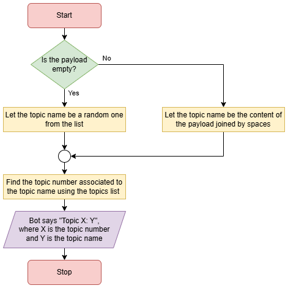

Note that one of the steps the flowchart involves making a random choice. You must import and make use of the `random` module from the Python Standard Library to do this. Consult [the documentation for the `random` module](https://docs.python.org/3/library/random.html) and select an appropriate function to use for this part of your solution. For information about importing modules, refer to Topic 9.

To find the index of an item in a list, use the `index()` list method. This method uses the list that `index()` is called on to search for the given argument in the list, and returns the index of the argument in the list. Here's an example of its usage in an interactive Python interpreter session:

```
>>> ['Hello', 'World'].index('Hello')
0
>>> ['How', 'Are', 'You?'].index('You?')
2
```

#### Examples for testing

Use the examples below, as well as your own examples, to test your code. The output from your chatbot should exactly match what is shown here.

```
bot_topic(['Algorithms', 'and', 'Flowcharts'])
```

**Chatbot:**  
Topic 1: Algorithms and Flowcharts

```
bot_topic([])
```

**Chatbot:**  
Topic 7: Data Structures

(Note: for this last example the selected topic is meant to be random, so your code should display different topics across different runs).

#### Criteria

- Correct definition of the list (as a constant). (4 marks)
- Correct function definition. (2 marks)
- Makes a random topic selection when the payload is empty using the `random` module. (3 marks)
- Uses the list to find the correct topic number. (2 marks)
- Displays the correct topic number and name for the given payload. (2 marks)
- Program behaviour otherwise matches the flowchart. (2 marks)

#### Your Solution

```python
# Add your import statement here.

# Define your constant here.

# Write your bot_topic() function here.


bot_topic(['Algorithms', 'and', 'Flowcharts'])    #=> Chatbot: Topic 1: Algorithms and Flowcharts
bot_topic([])     #=> Random. For example, Chatbot: Topic 7: Data Structures
```

#### [STAFF ONLY] Sample Solution

```python
# C6 note: If students get 2 marks for this based on decision element, however
#          have other elements not matching flow chart, then only award partial
#          marks

# C3: 1 mark for importing random module
import random

# C1: 1 mark for creating a list
# C1: 2 marks for correctly populating list (if not fully populated, award partial marks based on attempt)
# C1: 1 mark if variable name written in all capital letters
TOPICS = [
    'Algorithms and Flowcharts',
    'Statements and Expressions',
    'Booleans and Conditional Execution',
    'Iteration',
    'Functions and Objects',
    'Strings and Files',
    'Data Structures',
    'Software Errors',
    'Using Modules',
    'Structuring and Documenting Code',
    'Algorithm Design Strategies',
    'Revision',
]

# C2: 2 marks (1 for def and function name, 1 for parameter)
def bot_topic(payload):
    # C6: 1 mark for implementing the decision element correctly (based on length of payload)
    # C6: 1 mark for joining the payload with spaces
    if len(payload) > 0:
        topic_name = ' '.join(payload)
    else:
        # C3: 2 marks for randomly selecting a topic
        topic_name = random.choice(TOPICS)

    # C4: 2 marks for correctly finding index of topic
    topic_number = TOPICS.index(topic_name)

    # C5: 1 mark for correct topic number (i.e. adds 1 to convert index to position)
    # C5: 1 mark for correctly displaying topic name
    bot_say(f'Topic {topic_number + 1}: {topic_name}')

bot_topic(['Algorithms', 'and', 'Flowcharts'])
bot_topic([])
```

### Task 6: Chatbot command processor (15 marks)

Now that we have a few different chatbot command behaviours implemented, let's start tying everything together. We will do this in two parts. In this task, we will write a function which *dispatches* commands. That is, it looks at a command and determines which bot function to call. In the next task, we will use this function to build a simple simulated chat system with user input.

Firstly, create a dictionary constant which associates command names (strings) with function objects (command behaviours). For example, the key/value for the hello command should be `'!hello': bot_hello`. Importantly, the value should be the function name only (no brackets afterwards), otherwise Python will attempt to call the function during definition of the dictionary. There should be five commands in total from previous tasks.

Next, define a function called `dispatch_bot_command`. This function should have two parameters: the first is the name of the command (e.g. `"!whisper"`), and the second is the payload (e.g. `["I", "LOVE", "PYTHON"]`). The code inside the function should check whether the command is in the dictionary constant. If it is, it should call the associated function. If it is not, the bot should say "Unknown command" and the name of the unrecognised command.

*Hint: A function can be stored in a variable (or dictionary) just like any other kind of object, and can be called using that variable name instead of the function name. So if you retrieve a function from a dictionary and store it in a variable called `my_function`, you can call it using `my_function(...)`.*

#### Examples for testing

Use the examples below, as well as your own examples, to test your code. The output from your chatbot should exactly match what is shown here.

```
dispatch_bot_command('!hello', [])
```

**Chatbot:**  
Hello world!

```
dispatch_bot_command('!topic', ['Functions', 'and', 'Objects'])
```

**Chatbot:**  
Topic 5: Functions and Objects

[output not shown]

#### Criteria

- Correct definition of the dictionary constant. (5 marks)
- Correct function definition. (2 marks)
- Correct function behaviour. (4 marks)
- Function uses the dictionary to look up the function object associated with a command name. (2 marks)
- Appropriate output is produced for unknown commands. (2 marks)

#### Your Solution

```python
# Write your solution here.


dispatch_bot_command('!hello', [])     #=> Chatbot: Hello world!
dispatch_bot_command('!topic', ['Functions', 'and', 'Objects'])  #=> Chatbot: Topic 5: Functions and Objects
dispatch_bot_command('!fake', [])      #=> Chatbot: Unknown command !fake
```

#### [STAFF ONLY] Sample Solution

```python
# C1: 1 mark for creating a dictionary
# C1: 3 marks: 1.5 if keys entered correctly, 1.5 if values entered correctly
#     Only award partial marks if missing any key-value pairs
# C1: 1 mark if variable name written in all capital letters
BOT_COMMANDS = {
    '!hello': bot_hello,
    '!whisper': bot_whisper,
    '!multiply': bot_multiply,
    '!count': bot_count,
    '!topic': bot_topic,
}

# C2: 2 marks (1 for def and function name, 1 for parameter)
def dispatch_bot_command(command, payload):
    # C3: 2 marks for if-else statement (i.e. correctly checking if command exists)
    # C3: 1 mark for calling function object with the payload
    # C3: 1 mark if all code in function works as expected
    if command in BOT_COMMANDS:
        # C4: 2 marks for looking up function in dictionary
        function = BOT_COMMANDS[command]
        function(payload)
    else:
        # C5: 2 marks (1 for bot_say, 1 for correct format of output)
        bot_say(f'Unknown command: {command}')

dispatch_bot_command('!hello', [])
dispatch_bot_command('!topic', ['Functions', 'and', 'Objects'])
dispatch_bot_command('!fake', [])
```

### Task 7: Interactive chat loop (20 marks)

Implement an interactive loop which repeatedly asks for chat input, with the chatbot processing commands when appropriate. Your code should match the logic of the flowchart shown below:

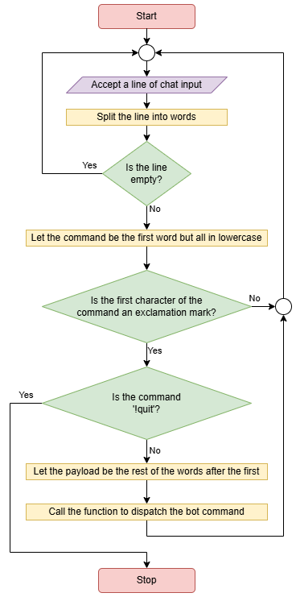

Instead of using the `input()` function to ask for user input, you should use the `chat_input()` function which has been defined for you already. This will result in a nicer looking chat log with colours. Here's an example of how to accept a line of input using this function:

```
line = chat_input()
```

To split the line into a list of individual words, use the `split()` string method. Here's an example:

```
>>> 'These are words'.split(' ')
['These', 'are', 'words']
```

*Note: If you run the code and it displays "You:" in blue text but no input text box appears, stop the code execution by clicking the stop symbol at the top-left of the cell and try running it again.*

#### Examples for testing

Use the examples below, as well as your own examples, to test your code. The output from your chatbot should exactly match what is shown here.

##### Example 1

**You:**  
I'm here!  
**You:**  
!whisper Keep this SECRET  
**Chatbot:**  
keep this secret  
**You:**  
!quit

##### Example 2

**You:**  
!HELLO  
**Chatbot:**  
Hello world!  
**You:**  
!QUIT

##### Example 3

**You:**  
!topic Functions and Objects  
**Chatbot:**  
Topic 5: Functions and Objects  
**You:**  
!quit

#### Criteria

- Repeatedly asks for user input using `chat_input()`. (4 marks)
- Case insensitive command recognition. (2 marks)
- Finishes gracefully on `!quit` command. (4 marks)
- Uses the `dispatch_bot_command()` function to dispatch other commands. (4 marks)
- Program behaviour otherwise matches the flowchart. (6 marks)

#### Your Solution

```python
# Write your solution here.
```

#### [STAFF ONLY] Sample Solution

```python
# C5: 1 mark for splitting the line into words
# C5: 2 marks for checking if the line is empty (i.e. pressing 'enter' should not crash the program)
# C5: 3 marks for otherwise following the flowchart. Full marks if all elements match, otherwise partial
# C5: Deduct marks/award partial marks accordingly for anything else that does not match flowchart

# C1: 2 marks if code loops repeatedly
while True:
    # C1: 2 marks for using chat_input() each iteration of the loop
    line = chat_input()
    words = line.strip().split(' ')
    if len(words) == 1 and words[0] == '':
        continue

    # C2: 2 marks for calling lower() on first string in payload (1 mark if doing it on entire payload)
    command = words[0].lower()
    # C3: 1 mark for checking if it command starts with a !
    if command[0] == '!':
        # C3: 1 mark for correctly identifying the !quit command
        if command == '!quit':
            # C3: 2 marks for using 'break' to gracefully exit loop
            break

        # C4: 2 marks for extracing all other words to be used as the payload
        payload = words[1:]
        # C4: 2 marks for calling dispatch_bot_command with correct arguments
        dispatch_bot_command(command, payload)
```

## Resetting the Notebook Runtime

Due to the nature of notebooks, old variables, classes and functions may still be accessible even after they have been removed from the code. This may result in unexpected program behaviour.

To ensure that this isn't the case, you can reset the runtime to reset the Python interpreter state. After doing so, you should run your solutions again to ensure they function correctly.

To reset the runtime, click the "Runtime" button in the menu at the top, then click "Restart runtime". Then, click "yes" in the following warning.

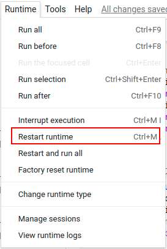

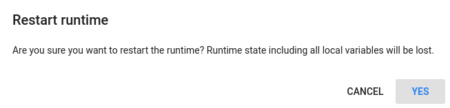